# Albert y Liam First Assignment

Liam McBride (liam.mcbride01@estudiant.upf.com)

Last update: 20 March, 2025

# Analysis of the Heart Disease Dataset

Load the data from [here](https://raw.githubusercontent.com/jpinero/DMI_2021/main/datasets/heart_disease_dataset.csv), and the description is [here](https://raw.githubusercontent.com/jpinero/DMI_2021/main/datasets/heart_disease_description.txt). The original dataset comes from [here](https://archive.ics.uci.edu/ml/datasets/Heart+Disease) and corresponds to the [processed cleveland data](https://archive.ics.uci.edu/ml/machine-learning-databases/heart-disease/processed.cleveland.data)

Here we analyze the heart disease dataset to identify key factors associated with heart disease. We start by performing an exploratory data analysis (EDA) to understand the distribution of numerical and categorical variables, detect outliers, and examine correlations. We will then create visualizations to highlight potential associations between features and heart disease.

## Perform an EDA on the dataset

### Data preparation

Before conducting our analysis, we clean and preprocess the dataset. This includes renaming columns for readability, converting categorical variables into meaningful labels, handling missing values, and removing outliers. One important decision we made was to categorize the disease diagnosis as positive vs negative to make it a binary categorical variable. In the original dataset there were several degrees of severity.

```r
# Reading in the Data
hdisease <- read.table("./data/heart_disease_dataset.csv", header=T)

# Transforming the data to ensure categorical and numerical variables are treated as such
hdisease1 <- hdisease %>%
  mutate(
    sex = ifelse(sex == 1, "male", "female"),
    cp = recode(cp, `1` = "typical angina", `2` = "atypical angina", `3` = "non-anginal pain", `4` = "asymptomatic"),
    fbs = ifelse(fbs == 1, T, F ),
    restecg = recode(restecg, `1` = "abnormal", `2` = "probable hypertrophy", `0` = "normal"),
    exang = ifelse(exang == 1, "yes", "no"),
    slope = recode(slope, `1` = "upsloping", `2` = "flat", `3` = "downsloping"),
    thal = recode(thal, `3` = "normal", `6` = "fixed defect", `7` = "reversible defect"),
    num = ifelse(num == 0, "negative diagnosis", "positive diagnosis")
  )

hdisease1$patient_id <- as.factor(hdisease1$patient_id)

# Rename columns for better readability
colnames(hdisease1) <- c("age", "sex", "chest_pain_type", "resting_bp", "cholesterol", "blood_sugar", "rest_ecg", "max_heart_rate", "exercise_induced_angina",
                         "peak", "slope", "num_major_vessels", "thalassemia", "diagnosis", "id")

# Changing missing values from "?" to "NA"
hdisease1[hdisease1 == "?"] <- NA

# Replace outliers
remove_outliers_column <- function(x) {
  iqr_val <- IQR(x, na.rm = TRUE)
  lower_bound <- quantile(x, 0.25, na.rm = TRUE) - 1.5 * iqr_val
  upper_bound <- quantile(x, 0.75, na.rm = TRUE) + 1.5 * iqr_val
  x[x < lower_bound] <- lower_bound
  x[x > upper_bound] <- upper_bound
  return(x)
}

columns_to_filter <- c("age", "cholesterol", "max_heart_rate", "resting_bp", "peak")

for (col in columns_to_filter) {
  hdisease1[[col]] <- remove_outliers_column(hdisease1[[col]])
}
```

### Numerical variables

To understand the distribution of numerical variables, we generate boxplots and density plots. This helps us identify potential outliers, assess whether the variables follow a normal distribution, and identify possible associations.

#### Create boxplots

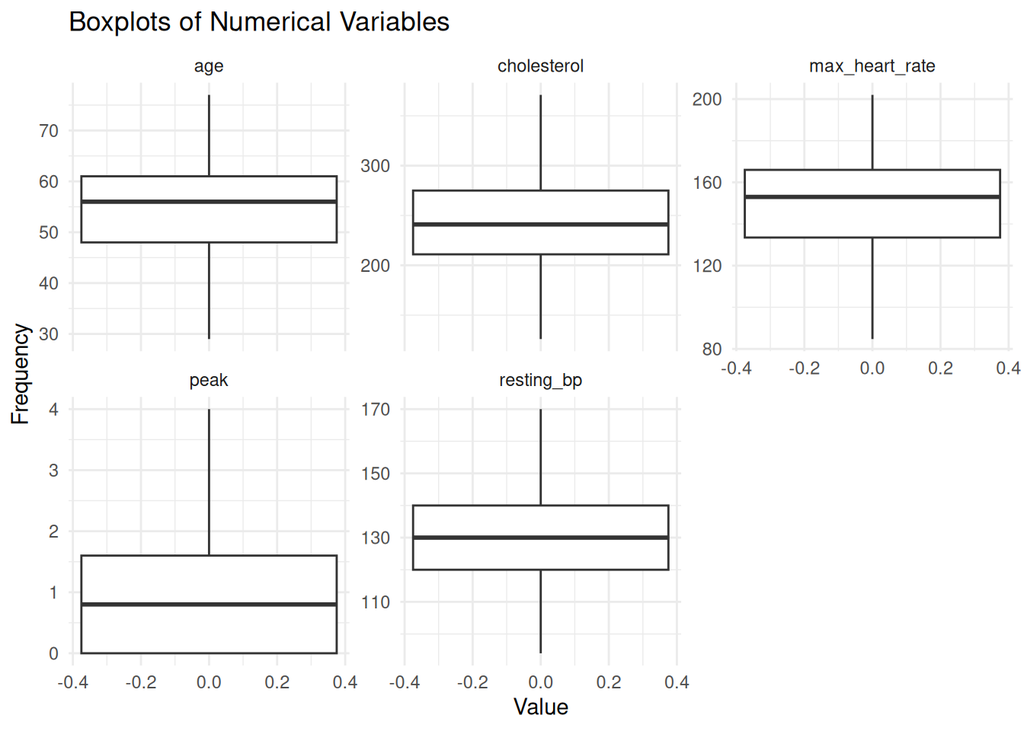

```r
numeric_vars <- hdisease1 %>%
  select(where(is.numeric))

numeric_vars %>%
  gather(key = "variable", value = "value") %>%
  ggplot(aes(y = value)) +
  geom_boxplot() +
  facet_wrap(~ variable, scales = "free_y") +
  theme_minimal() +
  labs(title = "Boxplots of Numerical Variables", x = "Value", y = "Frequency")
```

#### Density plots

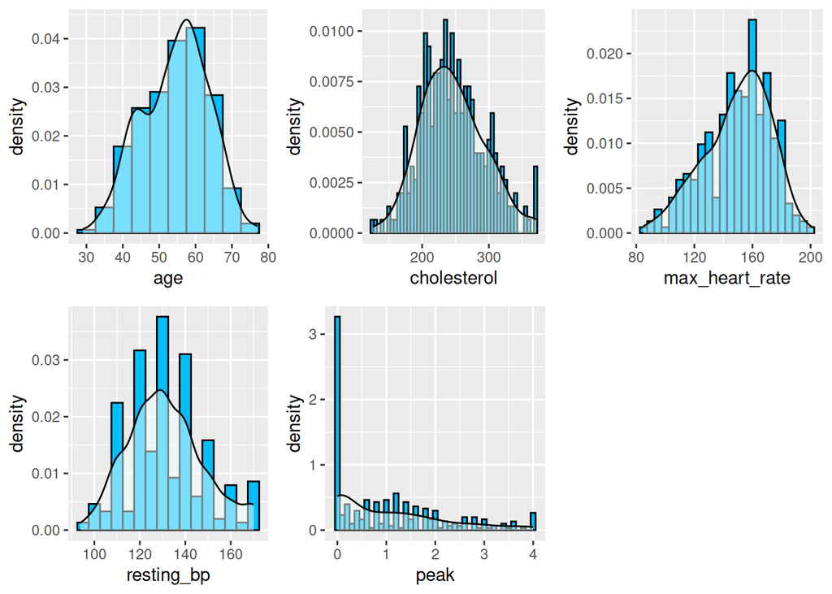

```r
# Create densityplots.
plot_Age <- ggplot(data = hdisease1, aes( x = age)) +
  geom_histogram(aes(y = ..density..), fill = 'deepskyblue1', color = 'black' ,binwidth = 5) +
  geom_density(fill = '#F0FFFF', alpha = 0.5)
plot_Cholestherol <- ggplot(data = hdisease1, aes( x = cholesterol)) +
  geom_histogram(aes(y = ..density..), fill = 'deepskyblue1', color = 'black' ,binwidth = 5) +
  geom_density(fill = '#F0FFFF', alpha = 0.5)
plot_MaxHeartRate <- ggplot(data = hdisease1, aes( x = max_heart_rate)) +
  geom_histogram(aes(y = ..density..), fill = 'deepskyblue1', color = 'black' , binwidth = 5) +
  geom_density(fill = '#F0FFFF', alpha = 0.5)
plot_RestingBloodPressure <- ggplot(data = hdisease1, aes( x = resting_bp)) +
  geom_histogram(aes(y = ..density..), fill = 'deepskyblue1', color = 'black' , binwidth = 5) +
  geom_density(fill = '#F0FFFF', alpha = 0.5)
plot_Peak <- ggplot(data = hdisease1, aes( x = peak)) +
  geom_histogram(aes(y = ..density..), fill = 'deepskyblue1', color = 'black', binwidth = 0.1) +
  geom_density(fill = '#F0FFFF', alpha = 0.5)

plot_grid(plot_Age,plot_Cholestherol,plot_MaxHeartRate,plot_RestingBloodPressure,plot_Peak, ncol = 3)
```

#### Q-Q Plots

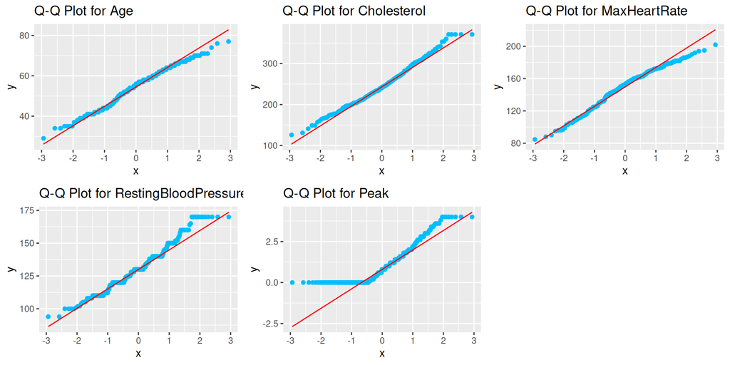

```r
# Create Q-Q plots.
qq_plot_Age <- ggplot(data = hdisease1, aes(sample = age)) +
  stat_qq(distribution = qnorm, color = 'deepskyblue1') +
  stat_qq_line(distribution = qnorm, color = 'red') +
  ggtitle("Q-Q Plot for Age")

qq_plot_Cholesterol <- ggplot(data = hdisease1, aes(sample = cholesterol)) +
  stat_qq(distribution = qnorm, color = 'deepskyblue1') +
  stat_qq_line(distribution = qnorm, color = 'red') +
  ggtitle("Q-Q Plot for Cholesterol")

qq_plot_MaxHeartRate <- ggplot(data = hdisease1, aes(sample = max_heart_rate)) +
  stat_qq(distribution = qnorm, color = 'deepskyblue1') +
  stat_qq_line(distribution = qnorm, color = 'red') +
  ggtitle("Q-Q Plot for MaxHeartRate")

qq_plot_RestingBloodPressure <- ggplot(data = hdisease1, aes(sample = resting_bp)) +
  stat_qq(distribution = qnorm, color = 'deepskyblue1') +
  stat_qq_line(distribution = qnorm, color = 'red') +
  ggtitle("Q-Q Plot for RestingBloodPressure")

qq_plot_Peak <- ggplot(data = hdisease1, aes(sample = peak)) +
  stat_qq(distribution = qnorm, color = 'deepskyblue1') +
  stat_qq_line(distribution = qnorm, color = 'red') +
  ggtitle("Q-Q Plot for Peak")

grid.arrange(qq_plot_Age, qq_plot_Cholesterol, qq_plot_MaxHeartRate,
             qq_plot_RestingBloodPressure, qq_plot_Peak, nrow = 2)
```

#### Normality tests

To determine if our numerical variables follow a normal distribution, we use the Shapiro-Wilk test. If the p-value is below 0.05, we reject the null hypothesis and conclude that the data is not normally distributed.

```r
# alpha 0.05
# Normality test for Age
shapiro_test_Age <- shapiro.test(hdisease1$age)
cat("Shapiro-Wilk test for Age:\n", "W =", shapiro_test_Age$statistic, ", p-value =", shapiro_test_Age$p.value, "\n\n")
```

```
## Shapiro-Wilk test for Age:
##  W = 0.9864633 , p-value = 0.006068642
```

```r
# Normality test for Cholestherol
shapiro_test_Cholestherol <- shapiro.test(hdisease1$cholesterol)
cat("Shapiro-Wilk test for Cholestherol:\n", "W =", shapiro_test_Cholestherol$statistic, ", p-value =", shapiro_test_Cholestherol$p.value, "\n\n")
```

```
## Shapiro-Wilk test for Cholestherol:
##  W = 0.9888511 , p-value = 0.02006615
```

```r
# Normality test for Max Heart Rate
shapiro_test_MaxHeartRate <- shapiro.test(hdisease1$max_heart_rate)
cat("Shapiro-Wilk test for Max heart rate:\n", "W =", shapiro_test_MaxHeartRate$statistic, ", p-value =", shapiro_test_MaxHeartRate$p.value, "\n\n")
```

```
## Shapiro-Wilk test for Max heart rate:
##  W = 0.9765386 , p-value = 7.244153e-05
```

```r
# Normality test for RestingBloodPressure
shapiro_test_RestingBloodPressure <- shapiro.test(hdisease1$resting_bp)
cat("Shapiro-Wilk test for Resting BP:\n", "W =", shapiro_test_RestingBloodPressure$statistic, ", p-value =", shapiro_test_RestingBloodPressure$p.value, "\n\n")
```

```
## Shapiro-Wilk test for Resting BP:
##  W = 0.9745627 , p-value = 3.309576e-05
```

```r
# Normality test for Peak
shapiro_test_Peak <- shapiro.test(hdisease1$peak)
cat("Shapiro-Wilk test for Peak:\n", "W =", shapiro_test_Peak$statistic, ", p-value =", shapiro_test_Peak$p.value, "\n\n")
```

```
## Shapiro-Wilk test for Peak:
##  W = 0.8517292 , p-value = 2.155173e-16
```

### Categorical variables

Next, we analyze categorical variables such as sex, chest pain type, and diagnosis. Understanding the distribution of these variables can provide insights into the characteristics of patients with heart disease.

```r
# Select categorical variables
categorical_vars <- hdisease1 %>%
  select_if(function(col) is.character(col) || is.logical(col))

# Convert the categorical variables to long format for plotting
categorical_vars_long <- categorical_vars %>%
  gather(key = "variable", value = "value")
```

#### Barplots

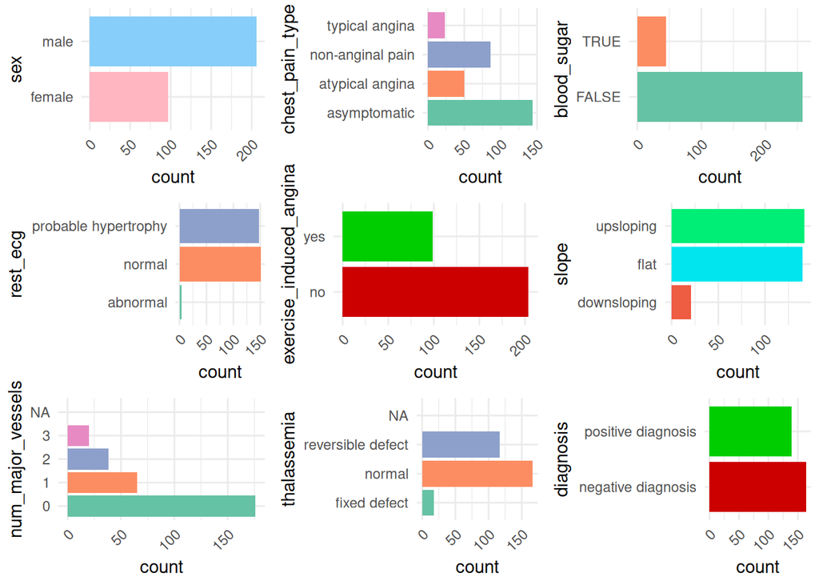

```r
# Function to create barplots for categorical variables
create_barplot <- function(data, var, fill_colors = NULL, angle = 45) {
  p <- ggplot(data, aes_string(x = var, fill = var)) +
    geom_bar() +
    theme_minimal() +
    theme(
      axis.text.x = element_text(angle = angle, hjust = 1),
      legend.position = "none",
      plot.margin=margin(t=5, b=5, r=5, l=5)
    ) +
    coord_flip()

  if (!is.null(fill_colors)) {
    p <- p + scale_fill_manual(values = fill_colors)
  } else {
    p <- p + scale_fill_brewer(palette = "Set2")
  }

  return(p)
}
# Create plots
plot_sex <- create_barplot(hdisease1, "sex", c("#FFB6C1", "#87CEFA"))
plot_chest_pain <- create_barplot(hdisease1, "chest_pain_type")
plot_fasting_blood_sugar <- create_barplot(hdisease1, "blood_sugar")
plot_resting_ec <- create_barplot(hdisease1, "rest_ecg")
plot_exercise_induced_angina <- create_barplot(hdisease1, "exercise_induced_angina", c("#CD0000", "#00CD00"))
plot_slope <- create_barplot(hdisease1, "slope", c("#EE5C42", "#00E5EE", "#00EE76"))
plot_major_vessels <- create_barplot(hdisease1, "num_major_vessels")
plot_thalassemia <- create_barplot(hdisease1, "thalassemia", NULL)
plot_diagnosis <- create_barplot(hdisease1, "diagnosis", c("#CD0000", "#00CD00"))

# Combine all plots into a grid
plot_grid(
  plot_sex, plot_chest_pain, plot_fasting_blood_sugar,
  plot_resting_ec, plot_exercise_induced_angina, plot_slope,
  plot_major_vessels, plot_thalassemia, plot_diagnosis,
  ncol = 3, rel_heights = c(1,1,1)
)
```

## Create visualizations in order to show which variables seem to be more associated with heart disease

To explore which features are most associated with heart disease, we visualize numerical variables against the diagnosis. Boxplots and barplots allow us to compare distributions between patients with and without heart disease.

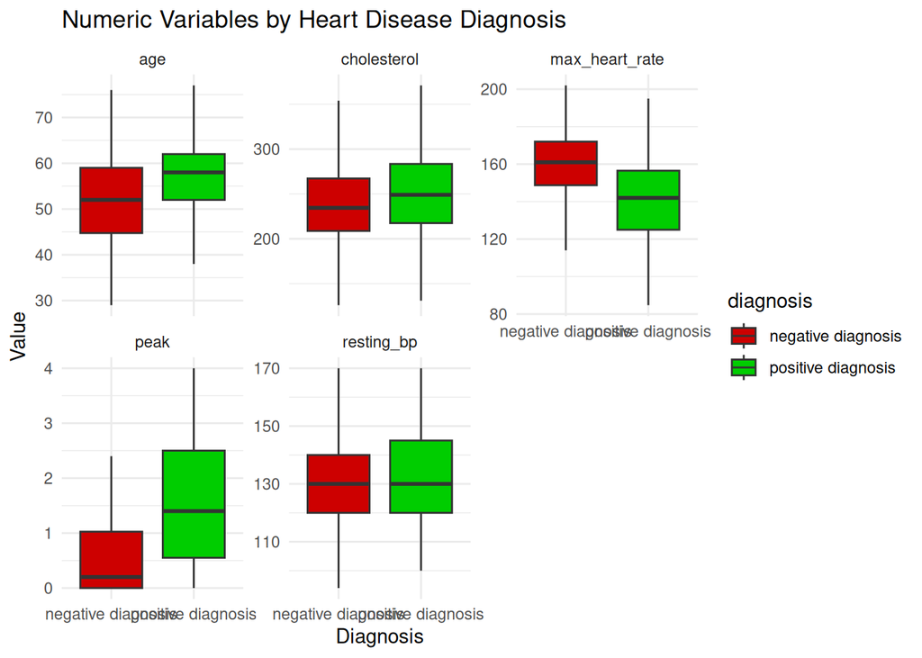

```r
numeric_vars_long <- numeric_vars %>%
  mutate(diagnosis = as.factor(hdisease1$diagnosis)) %>%
  pivot_longer(-diagnosis, names_to = "variable", values_to = "value")

boxplot_numeric <- ggplot(numeric_vars_long, aes(x = diagnosis, y = value, fill = diagnosis)) +
  geom_boxplot(outlier.shape = NA) +  # Avoid crazy outliers squishing plots
  facet_wrap(~ variable, scales = "free_y") +
  theme_minimal() +
  labs(title = "Numeric Variables by Heart Disease Diagnosis", x = "Diagnosis", y = "Value") +
  scale_fill_manual(values = c("#CD0000", "#00CD00"))

print(boxplot_numeric)
```

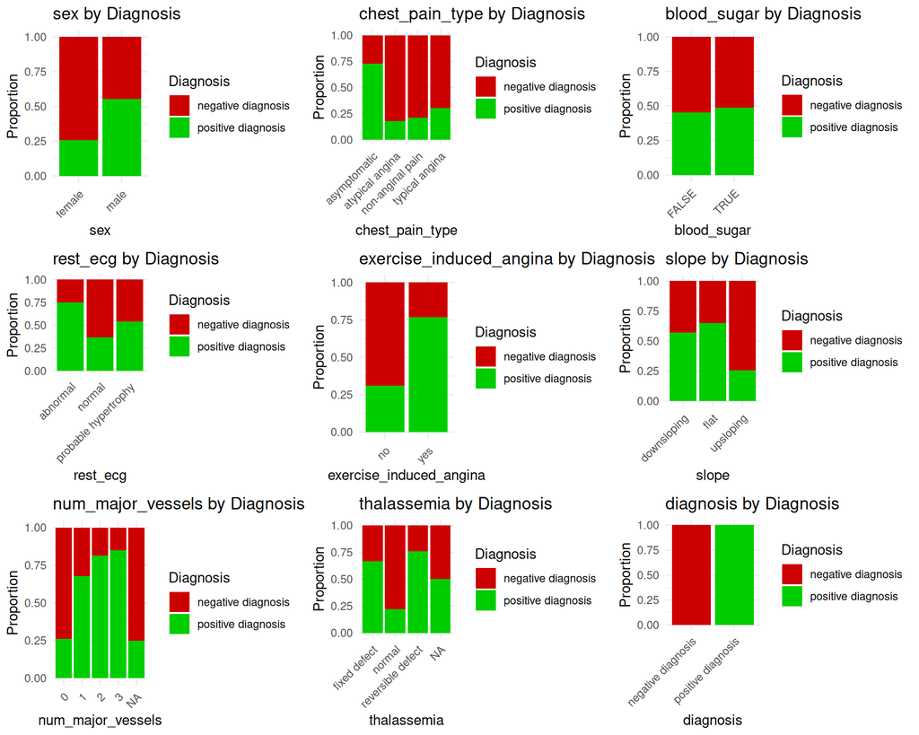

```r
# Define the plotting function
plot_categorical_barplot <- function(df, var) {
  ggplot(df, aes_string(x = var, fill = "as.factor(diagnosis)")) +
    geom_bar(position = "fill") +
    labs(title = paste(var, "by Diagnosis"), x = var, y = "Proportion") +
    scale_fill_manual(values = c("#CD0000", "#00CD00"), name = "Diagnosis") +
    theme_minimal() +
    theme(axis.text.x = element_text(angle = 45, hjust = 1))
}

# Loop through categorical variables and create the plots
cat_plots <- lapply(names(categorical_vars), function(cat_var) {
  plot_categorical_barplot(hdisease1, cat_var)
})

# Use plot_grid to arrange all plots in a grid
# You can adjust the number of columns (ncol) to suit your preferences
combined_plot <- plot_grid(plotlist = cat_plots, ncol = 3, align = 'v')  # Adjust ncol for layout

# Print the combined grid plot
print(combined_plot)
```

### Correlations

To quantify relationships between numerical features and heart disease, we compute correlation coefficients. Strong correlations may indicate potential predictors for heart disease diagnosis.

```r
# Convert Diagnosis to numeric
hdisease1_corr <- hdisease1 %>%
  mutate(
    diagnosis = ifelse(diagnosis == "negative diagnosis", 0, 1)
  )
numeric_vars_corr <- hdisease1_corr %>%
  select(where(is.numeric))
# Compute correlations
cor_matrix <- cor(numeric_vars_corr, use = "complete.obs")
cor_with_disease <- cor_matrix["diagnosis", , drop = FALSE]
cor_with_disease <- cor_with_disease[order(abs(cor_with_disease[, 1]), decreasing = TRUE), , drop = FALSE]

print("Correlation with Diagnosis:")
```

```
## [1] "Correlation with Diagnosis:"
```

```r
print(cor_with_disease)
```

```
##                 age resting_bp cholesterol max_heart_rate      peak diagnosis
## diagnosis 0.2231203  0.1449798   0.1038959     -0.4176241 0.4303088         1
```

```r
library(mlbench)
library("GGally")
```

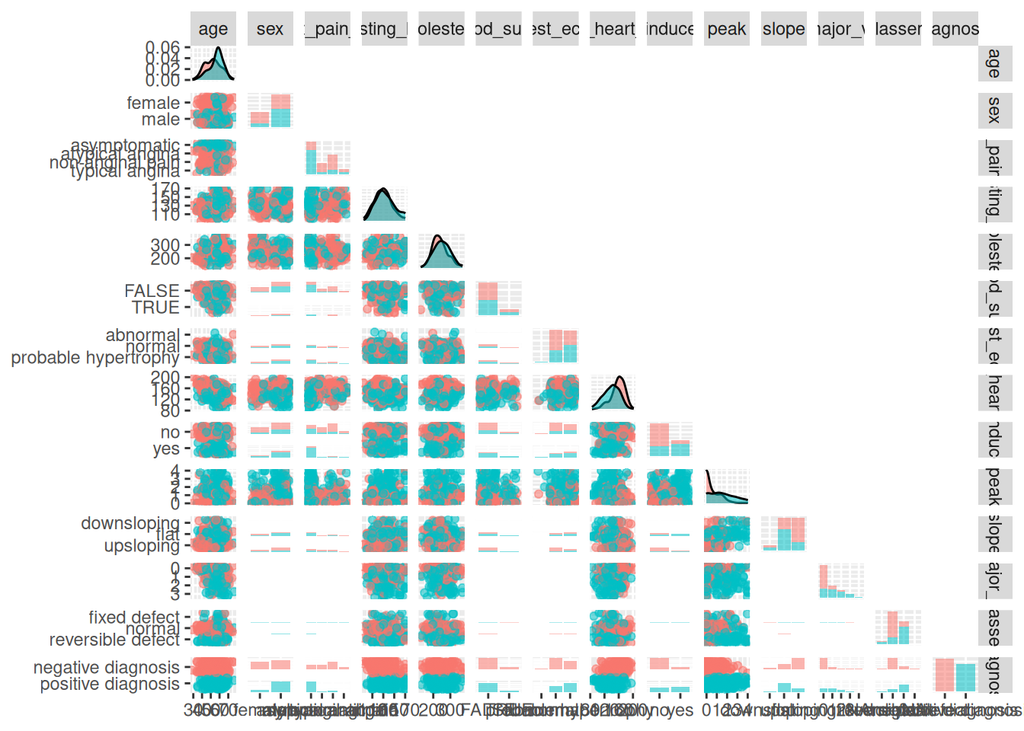

```r
ggpairs(hdisease1, aes(color = diagnosis, alpha = 0.5),
        columns = 1:14,  # select columns you want (or remove this line to use all columns)

        # Custom settings for each type of plot
        upper = list(continuous = wrap("blank"),
                     combo = wrap("blank"),
                     discrete = wrap("blank")),

        lower = list(continuous = wrap("points", alpha = 0.6),
                     combo = wrap("dot_no_facet"),
                     discrete = wrap("facetbar")),

        diag = list(continuous = wrap("densityDiag"),
                    discrete = wrap("barDiag"))
)
```

From the EDA we can observe associations between some of these variables and heart disease diagnosis. In general, males in this data set have a higher proportion of positive diagnoses. Those with exercise induced angina also tend to have higher proportions of positive diagnoses. Presence of thalassemia also appears to be associated with higher rates of positive diagnosis in this data set. In order to see if these variables could be used as predictors for likelihood of getting diagnosed with heart disease, further statistical tests would need to be performed.

# 2 Difference in mortality rates in hospitalized COVID-19 patients

Using the supplementary material from the [Difference in mortality rates in hospitalized COVID-19 patients identified by cytokine profile clustering using a machine learning approach: An outcome prediction alternative](https://www.frontiersin.org/articles/10.3389/fmed.2022.987182/full), perform the following tasks

## Reproduce Figure 1 from the publication

### Data preparation

```r
Table1 <- read_excel("data/Table1.xlsx", skip = 1)
Table1$Group = NA
Table1 <- Table1 %>%
  mutate(Group = case_when(
    `ARDS Diagnosis` == "No" & `Use of AMV`== "No" & `Use of NIV` == "No" ~ "G1",
    `ARDS Diagnosis` == "No" & (`Use of AMV` == "Yes" | `Use of AMV` == "No") & (`Use of NIV` == "Yes" | `Use of NIV` == "No") ~ "G2",
    `ARDS Diagnosis` == "Yes" & `Use of AMV`== "No" & `Use of NIV` == "Yes" ~ "G3",
    `ARDS Diagnosis` == "Yes" & `Use of AMV` == "Yes" & (`Use of NIV` == "Yes" | `Use of NIV` == "No") ~ "G4"
  ))
Table1 <- Table1 %>%
  distinct()
Table1 <- Table1 %>%
  filter(Death %in% c("Yes", "No"))
Table1 <- Table1 %>%
  count(ID) %>%
  filter(n == 1) %>%
  inner_join(Table1, by = "ID")
Table1 <- Table1 %>%
  filter(!is.na(Group))
```

### Figure 1A, Age Histogram

```r
fig1_a <- ggplot(Table1, aes(x = Age)) +
  geom_histogram(binwidth = 10, fill = "lightblue", color = "black") +
  scale_y_continuous(limits = c(0, 50)) +
  scale_x_continuous(breaks = seq(20, 100, by = 10), limits = c(20, 100)) +
  labs(x = "Age (years)", y = "Frequency (n)", title = "") +
  theme_minimal() +
  theme(axis.text.x = element_text(angle = 45, hjust = 1))
```

### Figure 1B, Definition of the Clinical Classifications

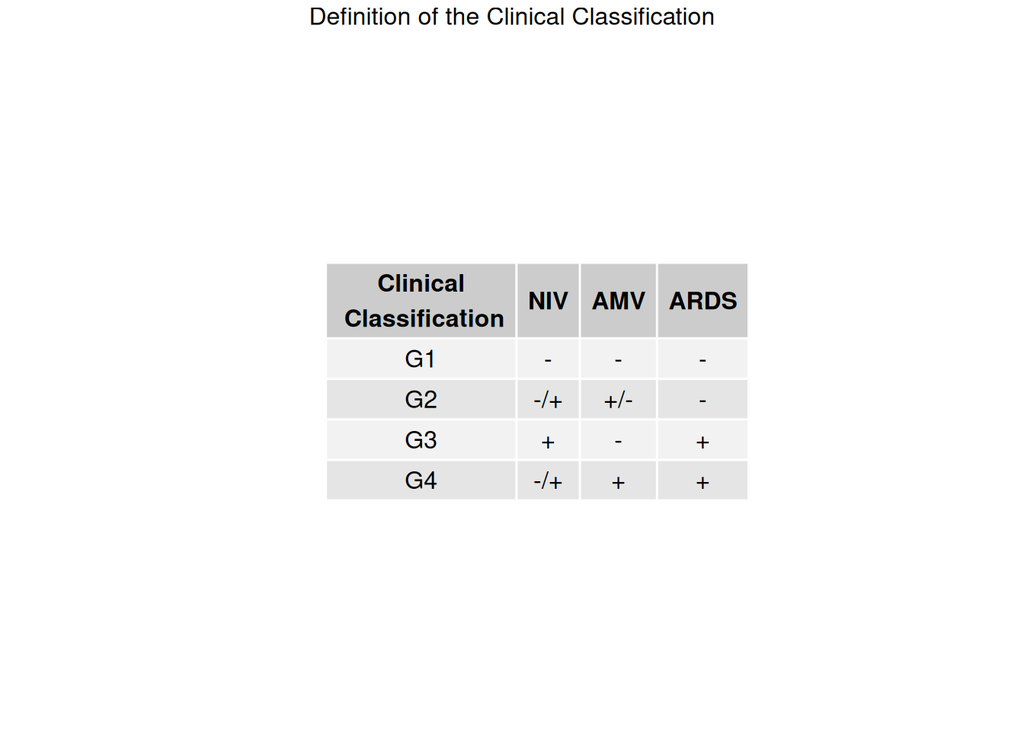

```r
first_column <- c("G1", "G2", "G3","G4")
second_column <- c("-", "-/+", "+","-/+")
third_column <- c("-", "+/-", "-","+")
forth_column <- c("-", "-", "+","+")
table1_classification <- data.frame(first_column, second_column, third_column, forth_column)
names = c("Clinical\n Classification", "NIV", "AMV", "ARDS")
colnames(table1_classification) <- names
rownames(table1_classification) <- c(" ","  ","   ","    ")

fig1_b <- grid.arrange(top="Definition of the Clinical Classification",tableGrob(table1_classification))
```

### FIgure 1C, Clinical Classification

```r
fig1_c <- ggplot(Table1, aes(x = Group, fill = Group)) +
  geom_bar() +
  geom_text(stat = "count", aes(label = after_stat(count)), vjust = -0.5) +
  labs(
    title = "Clinical Classification",
    x = "Clinical Classification",
    y = "Frequency (n)"
  ) +
  ylim(0,70)
```

### Figure 1D, Bar Chart of Death

```r
fig1_d <- ggplot(Table1, aes(x = Death)) +
  geom_bar(fill = "skyblue", color = "black") +
  geom_text(stat = "count", aes(label = after_stat(count)), vjust = -0.5) +
  labs(
    title = "Vital Status",
    x = "Death",
    y = "Frequency (n)"
  ) +
  ylim(0,150) +
  theme_minimal()
```

### Combined images

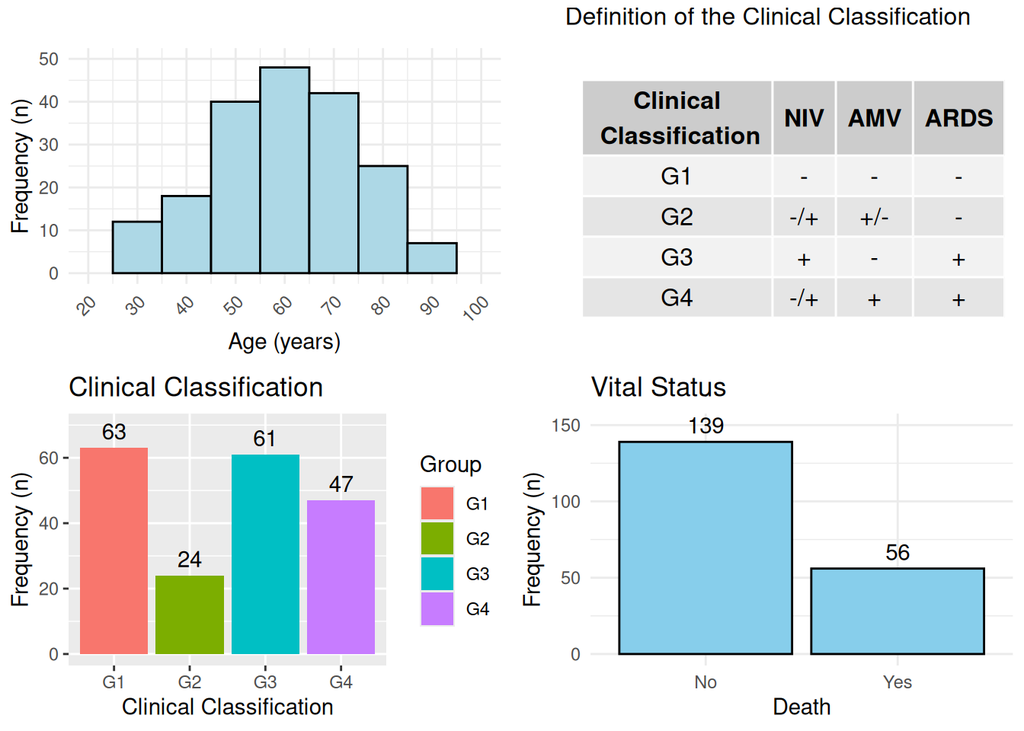

```r
# Convert ggplot objects to gtables and replace NULLs
plot_list <- list(fig1_a, fig1_b, fig1_c, fig1_d)

# Arrange plots in a 2-column layout
grid.arrange(grobs = plot_list, ncol = 2, heights = c(1, 1))
```

## Reproduce Figure 2 from the publication

but instead of representing the clusters in the annotation, represent the groups (G1 to G4)

```r
Table2 <- read_excel("data/Table2.xlsx", skip = 1)
#Cleaning Table 2:
#Change the first column name of "Table 2" to "ID"
colnames(Table2)[1] <- "ID"
# Remove rows with NA in the ID column and extract unique records.
Table2 <- Table2 %>%
  filter(!is.na(ID)) %>%
  distinct(ID, .keep_all = TRUE) %>%
  select(ID,`IL-6`,CXCL10,`IL-38`,`IL-8`,`IFN-ɑ`,`IL-10`,`TNF-ɑ`,CCL2,CCL3,`IFN-γ`,`IL-1β`,`G-CSF`)

# Define the columns to check as strings
columns_to_check <- c("IL-6", "CXCL10", "IL-38", "IL-8", "IFN-ɑ", "IL-10", "TNF-ɑ", "CCL2", "CCL3", "IFN-γ", "IL-1β", "G-CSF")

# Delete rows with characters in specified columns
unique_table2 <- Table2 %>%
  filter(!if_any(all_of(columns_to_check), ~grepl("^[A-Za-z]+$", .)))

# Delete the rows with "NI" in specified columns
unique_table2.2 <- unique_table2 %>%
  filter(!if_any(columns_to_check, ~grepl("NI", .)))
# Select the needed columns and rename the labels to make them more easy to handle
unique_table2.2 <- unique_table2.2 %>%
  select(ID,`IL-6`,CXCL10,`IL-38`,CCL3,`IFN-γ`,`IL-1β`,`IL-10`,`G-CSF`,`IFN-ɑ`
         ,`TNF-ɑ`,`IL-8`,CCL2) %>%
  rename_all(~ gsub("-", "", .)) %>%
  #Turn all non numeric values to NA
  mutate(across(-ID,as.numeric))

#Merge table 2 with classification from table 1 with ID.
table2_1_merged <- unique_table2.2 %>%
  inner_join(Table1 %>% select(ID, Group), by = "ID")
```

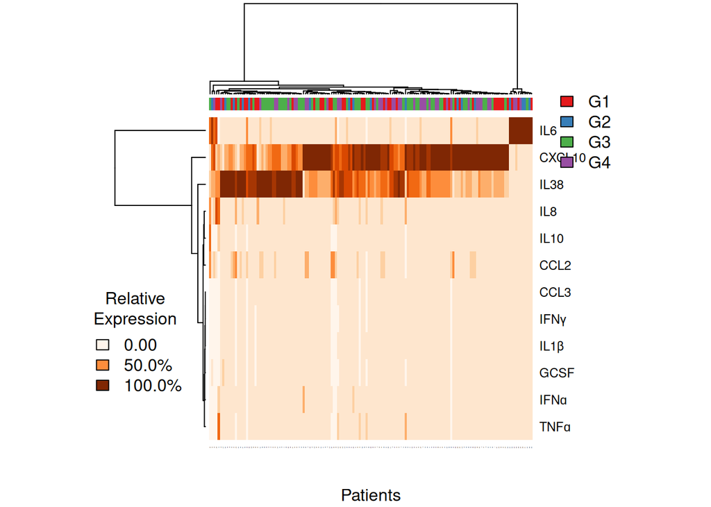

```r
#Define color pallette and assign a color to each group
color <- brewer.pal(4, "Set1")
classification_colors <- setNames(color, c("G1", "G2", "G3", "G4"))
classifications <- table2_1_merged$Group
classification_colside <- classification_colors[classifications]


#Plot using Heatmap
par(mar = c(5, 4, 4, 8), xpd = TRUE)

# Generate heatmap
heatmap_plot <- heatmap(
  as.matrix(t(table2_1_merged[, 2:13])),
  cexCol = 0.1,
  xlab = "Patients",
  col = brewer.pal(9, "Oranges"),
  scale = "column",
  ColSideColors = classification_colside
)

# Add the classification legend
legend("topright", inset = c(-0.15, 0), legend = c("G1", "G2", "G3", "G4"),
       fill = classification_colors, bty = "n")

# Add the color scale legend
legend("bottomleft", legend = c("0.00", "50.0%", "100.0%"),
       fill = brewer.pal(9, "Oranges")[c(1,5,9)], title = "Relative\nExpression",
       bty = "n")
```

## Improve figure 2 of the publication

Add a second annotation with information of death and a third one with information of gender

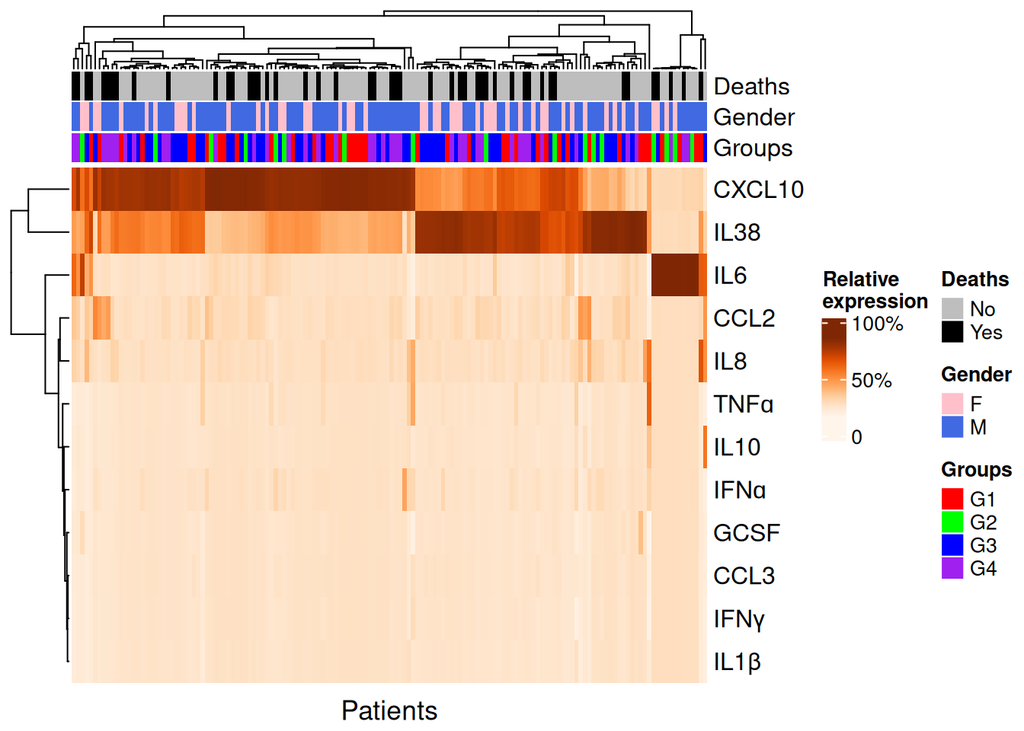

```r
#Clean table.
unique_table1.3 <- Table1 %>%
  filter(!is.na(ID)) %>%
  distinct(ID, .keep_all = TRUE)

#Merge by ID only columns of gender and death from Table 1.
table12_group_gender <- inner_join(
  table2_1_merged,
  unique_table1.3 %>% select(ID, Gender, Death),
  by = "ID"
)

#Remove numeric character and right strip space character.
table12_group_gender <- table12_group_gender %>%
  filter(!grepl("\\d", Gender))

#Get numeric data for Heatmap.
numeric_data <- table12_group_gender[, -c(1, 14, 15, 16)]

#Annotations.
gender_info <- table12_group_gender$Gender
death_info <- table12_group_gender$Death
classification_info <- table12_group_gender$Group
gender_info <- replace(gender_info, gender_info =="F ", "F")

ha <- HeatmapAnnotation(
    Deaths = death_info ,
    Gender = gender_info,
    Groups = classification_info,
    col = list(Deaths = c("Yes" = "black", "No" = "gray"),
               Groups = c("G1" = "red", "G2" = "green", "G3" = "blue", "G4" = "purple"),
               Gender = c("M" = "royalblue", "F" = "pink")
    )
)

Heatmap(
  scale(as.matrix(t(numeric_data))),
  name = "Relative\nexpression",
  column_title = "Patients",
  column_title_side = "bottom",
  top_annotation = ha,
  col = brewer.pal(9, "Oranges"),

  heatmap_legend_param = list(
    title = "Relative\nexpression",
    at = c(-2,1,4),
    labels = c("0", "50%", "100%")
  )

)
```

# session info

R version 4.4.1 (2024-06-14) Platform: x86_64-pc-linux-gnu Running under: Ubuntu 24.04.1 LTS

Matrix products: default BLAS: /usr/lib/x86_64-linux-gnu/blas/libblas.so.3.12.0 LAPACK: /usr/lib/x86_64-linux-gnu/lapack/liblapack.so.3.12.0

locale: [1] LC_CTYPE=en_US.UTF-8 LC_NUMERIC=C  
[3] LC_TIME=en_US.UTF-8 LC_COLLATE=en_US.UTF-8  
[5] LC_MONETARY=en_US.UTF-8 LC_MESSAGES=en_US.UTF-8  
[7] LC_PAPER=en_US.UTF-8 LC_NAME=C  
[9] LC_ADDRESS=C LC_TELEPHONE=C  
[11] LC_MEASUREMENT=en_US.UTF-8 LC_IDENTIFICATION=C

time zone: Europe/Madrid tzcode source: system (glibc)

attached base packages: [1] grid stats graphics grDevices utils datasets methods  
[8] base

other attached packages: [1] GGally_2.2.1 mlbench_2.1-6 survival_3.8-3  
[4] ggpubr_0.6.0 cluster_2.1.8 ggfortify_0.4.17  
[7] RColorBrewer_1.1-3 caret_7.0-1 lattice_0.22-6  
[10] gridExtra_2.3 ggplotify_0.1.2 circlize_0.4.16  
[13] ComplexHeatmap_2.20.0 readxl_1.4.3 outliers_0.15  
[16] DataExplorer_0.8.3 viridis_0.6.5 viridisLite_0.4.2  
[19] cowplot_1.1.3 lubridate_1.9.4 forcats_1.0.0  
[22] stringr_1.5.1 dplyr_1.1.4 purrr_1.0.2  
[25] readr_2.1.5 tidyr_1.3.1 tibble_3.2.1  
[28] ggplot2_3.5.1 tidyverse_2.0.0